# Case study: Evaluating the effectiveness of surrogates

# Introduction

In this case study, we illustrate the basic steps for evaluating the effectiveness of four environmental surrogates for four test features (ConiferBirds, DeciduousBirds, MixedwoodBirds, and GrasslandBirds) that occur in the boreal region of Canada. Specifically, we focus on the data preparation and analysis steps that are at the core of the surrogates evaluation. The examples focus on a set ecological benchmark networks that are located in one ecoregion in the boreal region (nets_rep.shp). All of the networks in the shapefile are representative of the four environmental surrogates. In the first analysis, we are interested in evaluating whether the top ranked network, based on the four surrogates, is also representative of our four test features. In the second analysis, we compare the previous approach with a complementary approach that focuses on maximizing reprensentation for the test features. All the required input data have already been generated and are located in the “data” folder. Please contact me (pierre.vernier@gmail.com) if you come across any problems trying to replicate this sample analysis.

# Data preparation

## Step 1 - Import libraries

We first need to import some libraries for reading and analysing raster and vector data, and three functions for calculating dissimilarity and representation metrics: *calcBC* for calculating the Bray-Curtis metric for categorical data, *calcKS* for calculating the Kolmogorov-Smirnov statistic for continuous data, and *calcRI* for calculating the representation index for continuous data. Those functions are in the main folder but you will also need to install the packages using the “install.packages” function i.e., install.packages(“sf”, “raster”, “tmap”, “tidyverse”).

```r
library(sf)
library(raster)
library(tmap)
library(tidyverse)
source("R/calcKS.R")
source("R/calcBC.R")
source("R/calcRI.R")
```

## Step 2 - Read datasets

We can now read the data into R. The study area consists of the ecoregion plus intersecting watersheds (FDAs). The ecoregion and FDA boundaries will be used as the reference areas in the analyses i.e., the region that the networks are compared to in terms of surrogates and test features. Networks are allowed to extend across ecoregion boundaries to enable hydrologic connectivity. The following datasets are available in the “data” folder:

- fda.shp - FDA boundary shapefile (extent of study area)
- eco.shp - Ecoregion boundary shapefile (extent of reference area within study area
- pas.shp - Existing protected areas shapefile
- nets_rep.shp - Candidate representative benchmarks networks shapefile
- ConiferBirds.tif - Density raster of bird species associated conifer forests
- DeciduousBirds.tif - Density raster of bird species associated with deciduous forests
- MixedwoodBirds.tif - Density raster of bird species associated with mixedwood forests
- GrasslandBirds.tif - Density raster of bird species associated with grasslands

```r
eco = st_read(paste0("eco",params$eco,"/eco.shp"), quiet=T) %>%
    mutate(legend="Ecoregion")
fda = st_read(paste0("eco",params$eco,"/fda.shp"), quiet=T) %>%
    st_union()
pas = st_read(paste0("eco",params$eco,"/pas.shp"), quiet=T) %>% mutate(legend="Protected areas")
nets = st_read(paste0("eco",params$eco,"/nets_rep.shp"), quiet=T) %>%
    st_transform(crs(fda)) %>%
    mutate(one=1, distance = sqrt(ks_cmi^2 + ks_gpp^2 + ks_led^2 + bc_lcc^2)/2) %>%
    arrange(distance)
net = slice_head(nets) %>%
    slice_head() %>%
    select(network) %>%
    mutate(legend="Sample network")
cmi = raster(paste0("eco",params$eco,"/cmi.tif"))
gpp = raster(paste0("eco",params$eco,"/gpp.tif"))
led = raster(paste0("eco",params$eco,"/led.tif"))
lcc = raster(paste0("eco",params$eco,"/lcc.tif"))
r1 = raster(paste0("eco",params$eco,"/ConiferBirds.tif"))
r1_median = round(cellStats(r1, median),1)
r1_min = round(cellStats(r1, min),1)
r1_max = round(cellStats(r1, max),1)
r2 = raster(paste0("eco",params$eco,"/DeciduousBirds.tif"))
r2_median = round(cellStats(r2, median),1)
r2_min = round(cellStats(r2, min),1)
r2_max = round(cellStats(r2, max),1)
r3 = raster(paste0("eco",params$eco,"/MixedwoodBirds.tif"))
r3_median = round(cellStats(r3, median),1)
r3_min = round(cellStats(r3, min),1)
r3_max = round(cellStats(r3, max),1)
r4 = raster(paste0("eco",params$eco,"/GrasslandBirds.tif"))
r4_median = round(cellStats(r4, median),1)
r4_min = round(cellStats(r4, min),1)
r4_max = round(cellStats(r4, max),1)
```

## Step 3 - View study area

The following map shows the location of ecoregion (grey) in the boreal region along with the extent of the intersecting watersheds (black outline), existing protected areas (green), and the sample network (red) comprising of 3 ecological benchmarks.

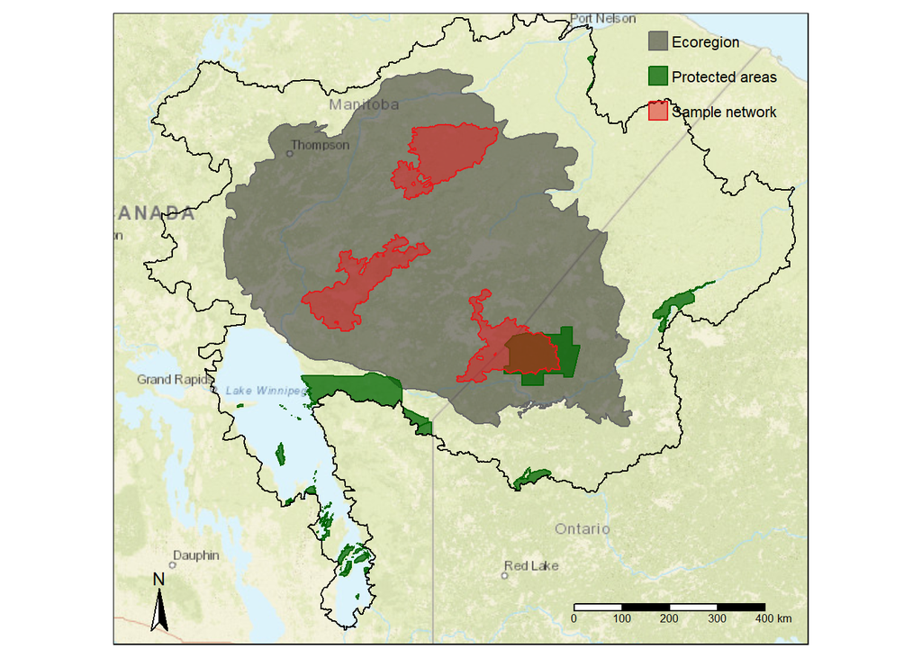

```r
osmtiles <- tmaptools::read_osm(fda, type="esri")
tm_shape(osmtiles) + tm_rgb() +
    tm_shape(eco) + tm_polygons(col="legend", title="", pal="#1D1D1D", alpha=0.5) +
    #tm_shape(pas) + tm_polygons(col="legend", title="", pal="#377EB8", border.col="#377EB8", alpha=1) +
    tm_shape(pas) + tm_polygons(col="legend", title="", pal="darkgreen", border.col="darkgreen", alpha=0.75) +
    tm_shape(net) + tm_polygons(col="legend", title="", pal="#E41A1C", border.col="#E41A1C", alpha=0.5) +
    tm_shape(fda) + tm_borders(lwd=1, col="black") +
    tm_legend(position = c("right", "top"), frame=FALSE) +
    tm_compass(position = c("left", "bottom")) +
    tm_scale_bar(position = c("right", "bottom"))
```

## Step 4 - Plot surrogates

The four plots show the distribution of climate moisture index (CMI), gross primary productivity (GPP), lake edge density (LED) and landcover (LCC) in the ecoregion and its intersecting watersheds. Note that the LCC map is a categorical map, but it has too many classes to properly display in the map’s legend below. The sample benchmark network is also shown on each map.

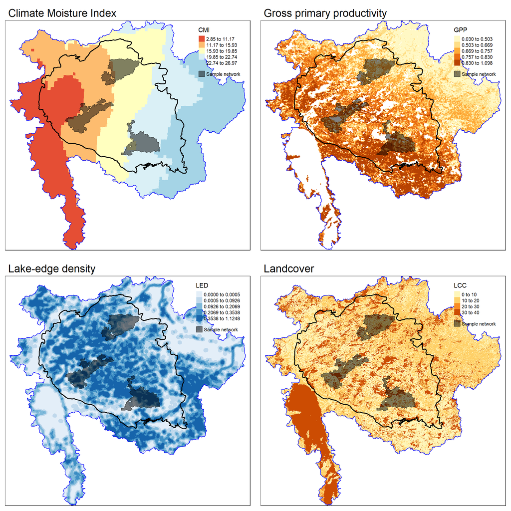

```r
net <- mutate(net, legend="Sample network")
tm1 <- tm_shape(cmi) + tm_raster(n=5, palette="RdYlBu", style="quantile", title = "CMI") +
    tm_shape(fda) + tm_borders(lwd=1, col="blue") +
    tm_shape(eco) + tm_borders(lwd=2, col="black") +
    tm_shape(net) + tm_polygons(col="legend", title="", pal="#000000", border.col="#000000", alpha=0.5, border.alpha=0.5) +
    tm_layout(main.title="Climate Moisture Index", legend.position = c("right", "top"))
tm2 <- tm_shape(gpp) + tm_raster(n=5, palette="YlOrBr", style="quantile", title = "GPP") +
    tm_shape(fda) + tm_borders(lwd=1, col="blue") +
    tm_shape(eco) + tm_borders(lwd=2, col="black") +
    tm_shape(net) + tm_polygons(col="legend", title="", pal="#000000", border.col="#000000", alpha=0.5, border.alpha=0.5) +
    tm_layout(main.title="Gross primary productivity", legend.position = c("right", "top"))
tm3 <- tm_shape(led) + tm_raster(palette="Blues", style="quantile", title = "LED") +
    tm_shape(fda) + tm_borders(lwd=1, col="blue") +
    tm_shape(eco) + tm_borders(lwd=2, col="black") +
    tm_shape(net) + tm_polygons(col="legend", title="", pal="#000000", border.col="#000000", alpha=0.5, border.alpha=0.5) +
    tm_layout(main.title="Lake-edge density", legend.position = c("right", "top"))
#lcc_pal = c(rgb(0,61,0, max=255), rgb(148,156,112, max=255), rgb(20,140,61, max=255), rgb(92,117,43, max=255), rgb(179,138,51, max=255), rgb(224,207,138, max=255), rgb(156,117,84, max=255), rgb(186,212,143, max=255), rgb(107,163,138, max=255), rgb(168,171,173, max=255), rgb(77,112,163, max=255))
tm4 <- tm_shape(lcc) + tm_raster(style="pretty", title="LCC") + # pal=lcc_pal, style='cat'
    tm_shape(fda) + tm_borders(lwd=1, col="blue") +
    tm_shape(eco) + tm_borders(lwd=2, col="black") +
    tm_shape(net) + tm_polygons(col="legend", title="", pal="#000000", border.col="#000000", alpha=0.5, border.alpha=0.5) +
    tm_layout(main.title="Landcover", legend.position = c("right", "top"))

print(tmap_arrange(tm1, tm2, tm3, tm4))
```

## Step 5 - Plot test features

The four plots show the distribution of density values for ConiferBirds, DeciduousBirds, MixedwoodBirds and GrasslandBirds in the ecoregion and its intersecting watersheds. The sample benchmark network is also shown on each map.

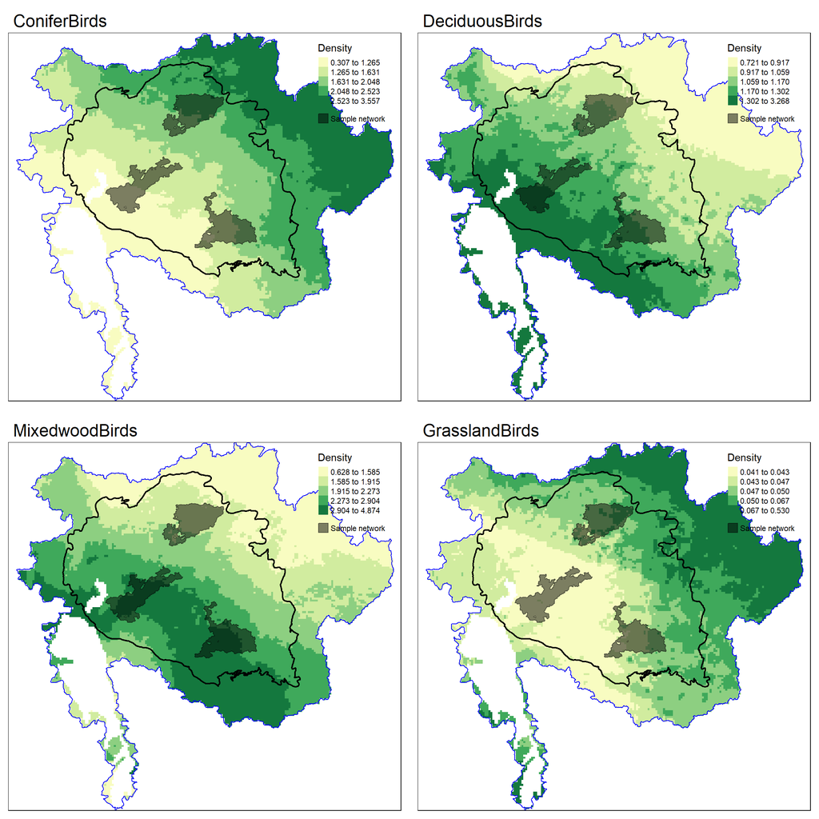

```r
tm1 <- tm_shape(r1) + tm_raster(palette="YlGn", style="quantile", title = "Density") +
    tm_shape(fda) + tm_borders(lwd=1, col="blue") +
    tm_shape(eco) + tm_borders(lwd=2, col="black") +
    tm_shape(net) + tm_polygons(col="legend", title="", pal="#000000", border.col="#000000", alpha=0.5, border.alpha=0.5) +
    tm_layout(main.title="ConiferBirds", title.position = c("left", "top"), legend.position = c("right", "top"), frame=T)
tm2 <- tm_shape(r2) + tm_raster(palette="YlGn", style="quantile", title = "Density") +
    tm_shape(fda) + tm_borders(lwd=1, col="blue") +
    tm_shape(eco) + tm_borders(lwd=2, col="black") +
    tm_shape(net) + tm_polygons(col="legend", title="", pal="#000000", border.col="#000000", alpha=0.5, border.alpha=0.5) +
    tm_layout(main.title="DeciduousBirds", title.position = c("left", "top"), legend.position = c("right", "top"), frame=T)
tm3 <- tm_shape(r3) + tm_raster(palette="YlGn", style="quantile", title = "Density") +
    tm_shape(fda) + tm_borders(lwd=1, col="blue") +
    tm_shape(eco) + tm_borders(lwd=2, col="black") +
    tm_shape(net) + tm_polygons(col="legend", title="", pal="#000000", border.col="#000000", alpha=0.5, border.alpha=0.5) +
    tm_layout(main.title="MixedwoodBirds", title.position = c("left", "top"), legend.position = c("right", "top"), frame=T)
tm4 <- tm_shape(r4) + tm_raster(palette="YlGn", style="quantile", title = "Density") +
    tm_shape(fda) + tm_borders(lwd=1, col="blue") +
    tm_shape(eco) + tm_borders(lwd=2, col="black") +
    tm_shape(net) + tm_polygons(col="legend", title="", pal="#000000", border.col="#000000", alpha=0.5, border.alpha=0.5) +
    tm_layout(main.title="GrasslandBirds", title.position = c("left", "top"), legend.position = c("right", "top"), frame=T)
print(tmap_arrange(tm1, tm2, tm3, tm4))
```

# Evaluating representativeness

In a “representativeness” analysis, we want to evaluate the representativeness of the sample network by comparing the distribution of values of each surrogate and test feature within the network to its distribution within the ecoregion (reference area).

## Step 6 - Calculate dissimilarity

```r
ks1 = calcKS(stack(cmi,gpp,led), eco, net)
bc1 = calcBC(lcc, eco, net)
ks2 = calcKS(stack(r1,r2,r3,r4), eco, net)
x1 = c("CMI","GPP","LED","LCC","ConiferBirds","DeciduousBirds","MixedwoodBirds","GrasslandBirds")
x2 = c("Climate moisture index","Gross primary productivity","Lake-edge density","Landcover","Conifer Birds","Deciduous Birds","Mixedwood Birds","Grassland Birds")
x3 = c("Surrogate","Surrogate","Surrogate","Surrogate","Test feature","Test feature","Test feature","Test feature")
x4 = c(unlist(ks1[2:4]), unlist(ks1[2]), unlist(ks2[2:5]))
df = tibble(Code=x1,Description=x2,Map_type=x3,Dissimilarity=sprintf("%.2f",x4))
names(df) <- c("Surrogate/Feature","Description","Map type","Dissimilarity")
knitr::kable(df, align="llll")
```

| Surrogate/Feature | Description | Map type | Dissimilarity |
| --- | --- | --- | --- |
| CMI | Climate moisture index | Surrogate | 0.12 |
| GPP | Gross primary productivity | Surrogate | 0.05 |
| LED | Lake-edge density | Surrogate | 0.05 |
| LCC | Landcover | Surrogate | 0.12 |
| ConiferBirds | Conifer Birds | Test feature | 0.10 |
| DeciduousBirds | Deciduous Birds | Test feature | 0.14 |
| MixedwoodBirds | Mixedwood Birds | Test feature | 0.25 |
| GrasslandBirds | Grassland Birds | Test feature | 0.13 |

In this example, the network we selected can be considered to be representative of the four surrogates using a threshold of 0.2 on a scale of 0-1, with lower values indicating increasing similarity. Other thresholds can be used. The KS values for the four test features are also shown in the far right column in the table. As with the surrogates, we consider test features to be representative if they have a KS values less than or equal to 0.2. In this case, we can consider that 3 of the 4 test features are also representative of the ecoregion, with MixedwoodBirds being slightly above the threshold. This example is based on a sample size of one. By repeating this for many networks, we can model the relationship between surrogates representativeness and test features representativeness to assess whether or not a relationship exists.

# Maximizing representation

In a “representation” analysis, we want to evaluate the representation of the sample network by calculating the proportion of values of each test feature within the network to its proportion with the ecoregion and intersecting watersheds (reference area).

## Step 7 - Calculate representation

In step 7, we calculate the representation index (RI) for the test features using the ratio of the proportion of test features in a network to the proportion of the network in the planning region:

A sample network is considered to be representative if the representation index has a value that is close to or greater than 1. The table below provides the results for the four test features using same network we used previously i.e., the top network based on the four surrogates. For this example, representation is considered to be adequate for all four test features.

```r
fda_dslv <- st_union(fda) # for RI, use the FDA boundary as reference area
ri1 = calcRI(stack(r1,r2,r3,r4), fda_dslv, net)
ri1v = unlist(ri1[2:5])
cat("Representation Index\n--------------------\n","ConiferBirds:", sprintf("%.2f",ri1v[1]), "\n","DeciduousBirds:", sprintf("%.2f",ri1v[2]), "\n","MixedwoodBrids:", sprintf("%.2f",ri1v[3]), "\n","GrasslandBirds:", sprintf("%.2f",ri1v[4]), "\n")
```

```
## Representation Index
## --------------------
##  ConiferBirds: 1.17
##  DeciduousBirds: 1.43
##  MixedwoodBrids: 1.56
##  GrasslandBirds: 1.02
```

## Step 8 - Maximize representation

If our focus is on maximizing representation for a particular test feature, we may want to calculate RI for all networks in the ecoregion, not just the top network based on the surrogates. We can then select the top network for each test feature. In the table below, we compare the KS and RI values for the top network (based on the surrogates) to the RI values for the top network overall i.e., among all networks in the shapefile.

```r
y = calcRI(stack(r1,r2,r3,r4), fda_dslv, nets)
#y2 = calcKS(stack(r1,r2,r3,r4), fda_dslv, nets)
#dm = left_join(left_join(left_join(ks1, ks2), bc1), ri1) %>%
#    mutate(distance = round(sqrt(cmi_ks^2 + gpp_ks^2 + led_ks^2 + lcc_bc^2)/2,3)) %>%
#    arrange(distance)
```

| Feature | Density (range) | Top “surrogate” network (KS) | Top “surrogate” network (RI) | Top overall network (RI) |
| --- | --- | --- | --- | --- |
| ConiferBirds | 1.80 (0.30-3.60) | 0.10 | 1.17 | 1.38 |
| DeciduousBirds | 1.10 (0.70-3.30) | 0.14 | 1.43 | 1.51 |
| MixedwoodBirds | 2.10 (0.60-4.90) | 0.25 | 1.56 | 1.76 |
| GrasslandBirds | 0.00 (0.00-0.50) | 0.13 | 1.02 | 1.26 |

The results indicate that, for each test feature, the best network for that feature came from the larger set of networks, not the top network that was representative for the four surrogates. The map below shows the location of the top network (based on representation index) in red for ConiferBirds, DeciduousBirds, MixedwoodBirds and GrasslandBirds. The sample networks used in the previous steps is also shown in grey.

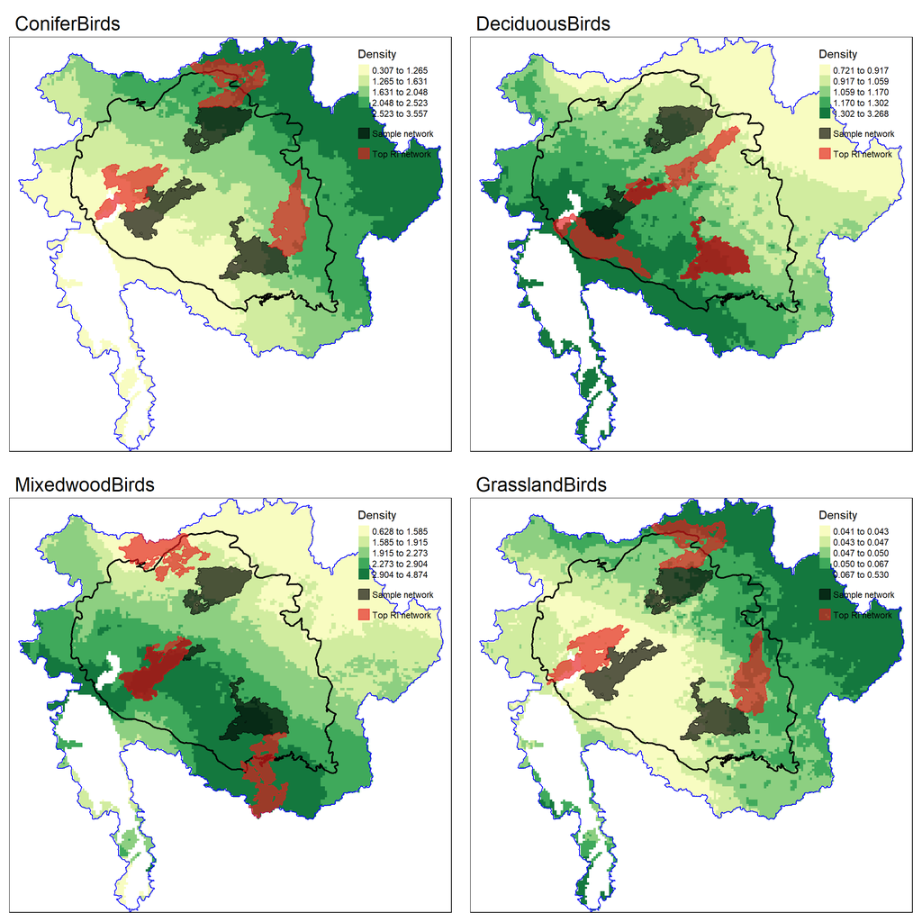

```r
# Select first "top" networks in case of ties
#topKS_ConiferBirds = y2$networks[y2$ConiferBirds_ks==max(y2$ConiferBirds_ks)][1]
#netKS_ConiferBirds = nets %>% filter(network==topKS_ConiferBirds) %>% mutate(legend="Top KS network")
#topKS_DeciduousBirds = y2$networks[y2$DeciduousBirds_ks==max(y2$DeciduousBirds_ks)][1]
#netKS_DeciduousBirds = nets %>% filter(network==topKS_DeciduousBirds) %>% mutate(legend="Top KS network")
#topKS_MixedwoodBirds = y2$networks[y2$MixedwoodBirds_ks==max(y2$MixedwoodBirds_ks)][1]
#netKS_MixedwoodBirds = nets %>% filter(network==topKS_MixedwoodBirds) %>% mutate(legend="Top KS network")
#topKS_GrasslandBirds = y2$networks[y2$GrasslandBirds_ks==max(y2$GrasslandBirds_ks)][1]
#netKS_GrasslandBirds = nets %>% filter(network==topKS_GrasslandBirds) %>% mutate(legend="Top KS network")

top_ConiferBirds = y$networks[y$ConiferBirds_ri==max(y$ConiferBirds_ri)][1]
net_ConiferBirds = nets %>% filter(network==top_ConiferBirds) %>% mutate(legend="Top RI network")
top_DeciduousBirds = y$networks[y$DeciduousBirds_ri==max(y$DeciduousBirds_ri)][1]
net_DeciduousBirds = nets %>% filter(network==top_DeciduousBirds) %>% mutate(legend="Top RI network")
top_MixedwoodBirds = y$networks[y$MixedwoodBirds_ri==max(y$MixedwoodBirds_ri)][1]
net_MixedwoodBirds = nets %>% filter(network==top_MixedwoodBirds) %>% mutate(legend="Top RI network")
top_GrasslandBirds = y$networks[y$GrasslandBirds_ri==max(y$GrasslandBirds_ri)][1]
net_GrasslandBirds = nets %>% filter(network==top_GrasslandBirds) %>% mutate(legend="Top RI network")

tm1 <- tm_shape(r1) + tm_raster(palette="YlGn", style="quantile", title = "Density") +
    tm_shape(fda) + tm_borders(lwd=1, col="blue") +
    tm_shape(eco) + tm_borders(lwd=2, col="black") +
    tm_shape(net) + tm_polygons(col="legend", title="", pal="#000000", border.col="#000000", alpha=0.65, border.alpha=0.65) +
    #tm_shape(netKS_ConiferBirds) + tm_polygons(col="legend", title="", pal="blue", border.col="blue", alpha=0.65, border.alpha=0.65) +
    tm_shape(net_ConiferBirds) + tm_polygons(col="legend", title="", pal="#E41A1C", border.col="#E41A1C", alpha=0.65, border.alpha=0.65) +
    tm_layout(main.title="ConiferBirds", title.position = c("left", "top"), legend.position = c("right", "top"), frame=T)
tm2 <- tm_shape(r2) + tm_raster(palette="YlGn", style="quantile", title = "Density") +
    tm_shape(fda) + tm_borders(lwd=1, col="blue") +
    tm_shape(eco) + tm_borders(lwd=2, col="black") +
    tm_shape(net) + tm_polygons(col="legend", title="", pal="#000000", border.col="#000000", alpha=0.65, border.alpha=0.65) +
    #tm_shape(netKS_DeciduousBirds) + tm_polygons(col="legend", title="", pal="blue", border.col="blue", alpha=0.65, border.alpha=0.65) +
    tm_shape(net_DeciduousBirds) + tm_polygons(col="legend", title="", pal="#E41A1C", border.col="#E41A1C", alpha=0.65, border.alpha=0.65) +
    tm_layout(main.title="DeciduousBirds", title.position = c("left", "top"), legend.position = c("right", "top"), frame=T)
tm3 <- tm_shape(r3) + tm_raster(palette="YlGn", style="quantile", title = "Density") +
    tm_shape(fda) + tm_borders(lwd=1, col="blue") +
    tm_shape(eco) + tm_borders(lwd=2, col="black") +
    tm_shape(net) + tm_polygons(col="legend", title="", pal="#000000", border.col="#000000", alpha=0.65, border.alpha=0.65) +
    #tm_shape(netKS_MixedwoodBirds) + tm_polygons(col="legend", title="", pal="blue", border.col="blue", alpha=0.65, border.alpha=0.65) +
    tm_shape(net_MixedwoodBirds) + tm_polygons(col="legend", title="", pal="#E41A1C", border.col="#E41A1C", alpha=0.65, border.alpha=0.65) +
    tm_layout(main.title="MixedwoodBirds", title.position = c("left", "top"), legend.position = c("right", "top"), frame=T)
tm4 <- tm_shape(r4) + tm_raster(palette="YlGn", style="quantile", title = "Density") +
    tm_shape(fda) + tm_borders(lwd=1, col="blue") +
    tm_shape(eco) + tm_borders(lwd=2, col="black") +
    tm_shape(net) + tm_polygons(col="legend", title="", pal="#000000", border.col="#000000", alpha=0.65, border.alpha=0.65) +
    #tm_shape(netKS_GrasslandBirds) + tm_polygons(col="legend", title="", pal="blue", border.col="blue", alpha=0.65, border.alpha=0.65) +
    tm_shape(net_GrasslandBirds) + tm_polygons(col="legend", title="", pal="#E41A1C", border.col="#E41A1C", alpha=0.65, border.alpha=0.65) +
    tm_layout(main.title="GrasslandBirds", title.position = c("left", "top"), legend.position = c("right", "top"), frame=T)
print(tmap_arrange(tm1, tm2, tm3, tm4))
```